# Prediction Assignment

Mark Stouffer

September 12, 2018

## Background

Using devices such as Jawbone Up, Nike FuelBand, and Fitbit it is now possible to collect a large amount of data about personal activity relatively inexpensively. These type of devices are part of the quantified self movement a group of enthusiasts who take measurements about themselves regularly to improve their health, to find patterns in their behavior, or because they are tech geeks. One thing that people regularly do is quantify how much of a particular activity they do, but they rarely quantify how well they do it. In this project, your goal will be to use data from accelerometers on the belt, forearm, arm, and dumbell of 6 participants. They were asked to perform barbell lifts correctly and incorrectly in 5 different ways. More information is available from the website here: http://web.archive.org/web/20161224072740/http:/groupware.les.inf.puc-rio.br/har (see the section on the Weight Lifting Exercise Dataset).

## Data

The training data for this project are available here: https://d396qusza40orc.cloudfront.net/predmachlearn/pml-training.csv

The test data are available here: https://d396qusza40orc.cloudfront.net/predmachlearn/pml-testing.csv

The data for this project come from this source: http://web.archive.org/web/20161224072740/http:/groupware.les.inf.puc-rio.br/har. If you use the document you create for this class for any purpose please cite them as they have been very generous in allowing their data to be used for this kind of assignment.

## What you should submit

The goal of your project is to predict the manner in which they did the exercise. This is the “classe” variable in the training set. You may use any of the other variables to predict with. You should create a report describing how you built your model, how you used cross validation, what you think the expected out of sample error is, and why you made the choices you did. You will also use your prediction model to predict 20 different test cases.

## Setting up the data

First, I download some packages, load the data, and set the seed as follows:

```r
library(caret)
library(randomForest)
```

```r
library(rpart)
library(rpart.plot)
pml_training <- read.csv("pml-training.csv", na.strings=c("NA","#DIV/0!", ""))
pml_testing <- read.csv("pml-testing.csv", na.strings=c("NA","#DIV/0!", ""))
set.seed(1234)
dim(pml_training)
```

```
## [1] 19622   160
```

```r
dim(pml_testing)
```

```
## [1]  20 160
```

## Cleaning Up Data

We now clean up the data, getting rid of some unneccessary variables and NA values are taken out.

```r
pml_training<-pml_training[,colSums(is.na(pml_training)) == 0]
pml_testing <-pml_testing[,colSums(is.na(pml_testing)) == 0]
pml_training<-pml_training[,-c(1:7)]
pml_testing<-pml_testing[,-c(1:7)]
dim(pml_training)
```

```
## [1] 19622    53
```

```r
dim(pml_testing)
```

```
## [1] 20 53
```

## Cross-validation

Then, we split the data into training and testing, with a 0.75 and 0.25 split.

```r
subsamples <- createDataPartition(y=pml_training$classe, p=0.75, list=FALSE)
pml_trainingsub <- pml_training[subsamples, ]
pml_testingsub <- pml_training[-subsamples, ]
```

## Exploratory Data Analysis

We now look at a graph to see the distribution of classe variables:

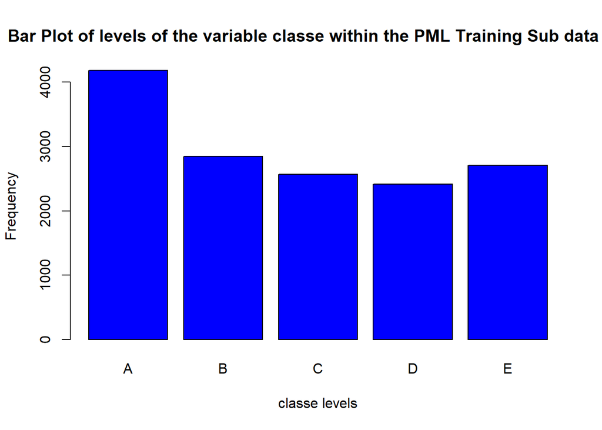

```r
plot(pml_trainingsub$classe, col="blue", main="Bar Plot of levels of the variable classe within the PML Training Sub data set", xlab="classe levels", ylab="Frequency")
```

As you can see, A is the most frequent by a lot, and D is the least frequent.

## Prediction Models

We will do two prediction models: a Decision Tree and a Random Forest.

## Decision Tree

Here we get both the Decision Tree and a Confusion Matrix that gives a numerical breakdown.

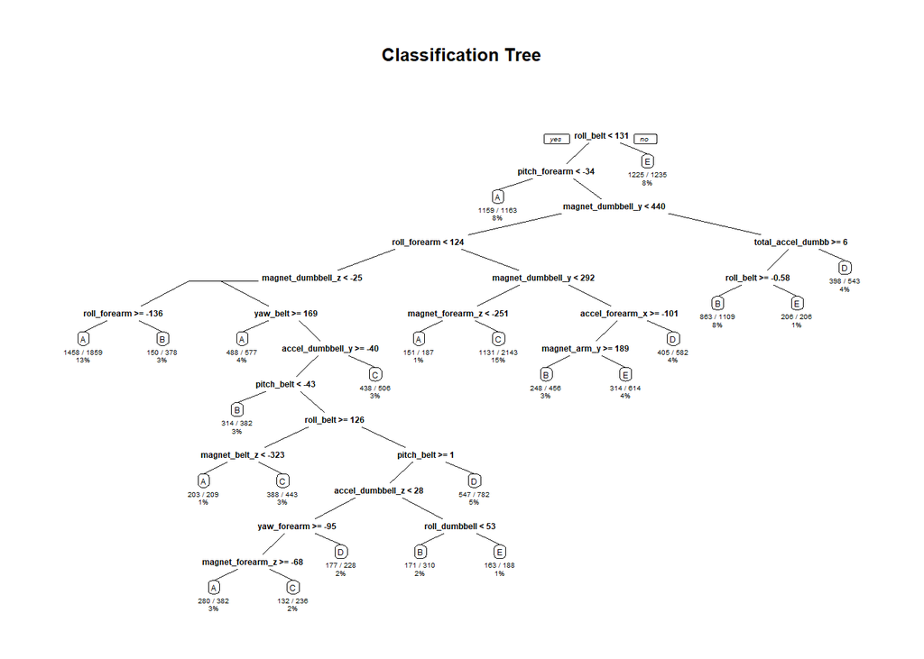

```r
firstmodel <- rpart(classe ~ ., data=pml_trainingsub, method="class")
firstprediction <- predict(firstmodel, pml_testingsub, type = "class")
prp(firstmodel, main="Classification Tree", extra=102, under=TRUE, faclen=0)
```

```r
confusionMatrix(firstprediction, pml_testingsub$classe)
```

```
## Confusion Matrix and Statistics
##
##           Reference
## Prediction    A    B    C    D    E
##          A 1235  157   16   50   20
##          B   55  568   73   80  102
##          C   44  125  690  118  116
##          D   41   64   50  508   38
##          E   20   35   26   48  625
##
## Overall Statistics
##
##                Accuracy : 0.7394
##                  95% CI : (0.7269, 0.7516)
##     No Information Rate : 0.2845
##     P-Value [Acc > NIR] : < 2.2e-16
##
##                   Kappa : 0.6697
##  Mcnemar's Test P-Value : < 2.2e-16
##
## Statistics by Class:
##
##                      Class: A Class: B Class: C Class: D Class: E
## Sensitivity            0.8853   0.5985   0.8070   0.6318   0.6937
## Specificity            0.9307   0.9216   0.9005   0.9529   0.9678
## Pos Pred Value         0.8356   0.6469   0.6313   0.7247   0.8289
## Neg Pred Value         0.9533   0.9054   0.9567   0.9296   0.9335
## Prevalence             0.2845   0.1935   0.1743   0.1639   0.1837
## Detection Rate         0.2518   0.1158   0.1407   0.1036   0.1274
## Detection Prevalence   0.3014   0.1790   0.2229   0.1429   0.1538
## Balanced Accuracy      0.9080   0.7601   0.8537   0.7924   0.8307
```

## Random Forest

Now, the Random Forest, with the same process.

```r
secondmodel <- randomForest(classe ~. , data=pml_trainingsub, method="class")
importance(secondmodel)
```

```
##                      MeanDecreaseGini
## roll_belt                   958.94321
## pitch_belt                  528.45759
## yaw_belt                    673.43084
## total_accel_belt            177.52822
## gyros_belt_x                 73.74342
## gyros_belt_y                 85.30123
## gyros_belt_z                236.84163
## accel_belt_x                 89.79044
## accel_belt_y                 91.83153
## accel_belt_z                299.23056
## magnet_belt_x               183.36875
## magnet_belt_y               264.90329
## magnet_belt_z               303.15576
## roll_arm                    236.10351
## pitch_arm                   129.03823
## yaw_arm                     189.45954
## total_accel_arm              76.69898
## gyros_arm_x                  98.60400
## gyros_arm_y                 105.34601
## gyros_arm_z                  42.33839
## accel_arm_x                 185.25499
## accel_arm_y                 118.95514
## accel_arm_z                  97.71151
## magnet_arm_x                187.88288
## magnet_arm_y                170.83084
## magnet_arm_z                139.86519
## roll_dumbbell               318.49616
## pitch_dumbbell              134.48164
## yaw_dumbbell                192.63342
## total_accel_dumbbell        198.63443
## gyros_dumbbell_x             95.71824
## gyros_dumbbell_y            188.27358
## gyros_dumbbell_z             65.79974
## accel_dumbbell_x            174.63712
## accel_dumbbell_y            301.53773
## accel_dumbbell_z            251.79135
## magnet_dumbbell_x           365.82140
## magnet_dumbbell_y           513.75987
## magnet_dumbbell_z           549.42544
## roll_forearm                447.01673
## pitch_forearm               582.87577
## yaw_forearm                 134.70884
## total_accel_forearm          90.79311
## gyros_forearm_x              56.28900
## gyros_forearm_y              94.67395
## gyros_forearm_z              65.25446
## accel_forearm_x             237.00708
## accel_forearm_y             104.86183
## accel_forearm_z             181.43700
## magnet_forearm_x            164.88718
## magnet_forearm_y            168.17617
## magnet_forearm_z            211.92462
```

```r
secondprediction <- predict(secondmodel, pml_testingsub, type = "class")
confusionMatrix(secondprediction, pml_testingsub$classe)
```

```
## Confusion Matrix and Statistics
##
##           Reference
## Prediction    A    B    C    D    E
##          A 1395    3    0    0    0
##          B    0  943   10    0    0
##          C    0    3  844    5    0
##          D    0    0    1  799    0
##          E    0    0    0    0  901
##
## Overall Statistics
##
##                Accuracy : 0.9955
##                  95% CI : (0.9932, 0.9972)
##     No Information Rate : 0.2845
##     P-Value [Acc > NIR] : < 2.2e-16
##
##                   Kappa : 0.9943
##  Mcnemar's Test P-Value : NA
##
## Statistics by Class:
##
##                      Class: A Class: B Class: C Class: D Class: E
## Sensitivity            1.0000   0.9937   0.9871   0.9938   1.0000
## Specificity            0.9991   0.9975   0.9980   0.9998   1.0000
## Pos Pred Value         0.9979   0.9895   0.9906   0.9988   1.0000
## Neg Pred Value         1.0000   0.9985   0.9973   0.9988   1.0000
## Prevalence             0.2845   0.1935   0.1743   0.1639   0.1837
## Detection Rate         0.2845   0.1923   0.1721   0.1629   0.1837
## Detection Prevalence   0.2851   0.1943   0.1737   0.1631   0.1837
## Balanced Accuracy      0.9996   0.9956   0.9926   0.9968   1.0000
```

## Decision on which Prediction Model to Use

Random Forest algorithm performed better than Decision Trees. Accuracy for Random Forest model was 0.995 (95% CI: (0.993, 0.997)) compared to Decision Tree model with 0.739 (95% CI: (0.727, 0.752)). The Random Forests model is choosen. The expected out-of-sample error is estimated at 0.005, or 0.5%. So the high majority of these points are correctly classified.

## Final Outcome

Here is the final prediction using the Random Forest Model.

```r
finalprediction <- predict(secondmodel, pml_testing, type="class")
finalprediction
```

```
##  1  2  3  4  5  6  7  8  9 10 11 12 13 14 15 16 17 18 19 20
##  B  A  B  A  A  E  D  B  A  A  B  C  B  A  E  E  A  B  B  B
## Levels: A B C D E
```